# Visualization of Maternal Mortality

Short Paper Assignment

Andrea L. Koch

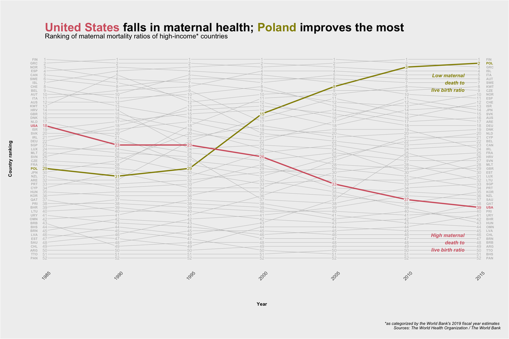

```r
rm(list=ls())

library(tidyverse)
library(dplyr)
library(CGPfunctions)
# require(dplyr)
# require(ggplot2)
# require(ggrepel)
# require(kableExtra)
library(ggplot2)
library(ggrepel)
library(kableExtra)
library(readxl)
library(sqldf)
library(scales)
# library(plyr)
# remove plyr with detach(package:plyr)
# cannot load plyr after dplyr -- will cause issues with drply group_by

setwd("~/Desktop/Data Visualization/DV Maternal Mortality")


#######################
#      BUMPCHART      #
#  plot upper income  #
#######################

####  Filter and merge data:

WHO_data <- read.csv("data/WHO_MMR-data-1990-2015 (1)/countryresults_all.csv")

# New table of mmr point estimates:
mmr_data <- filter(WHO_data,
                     indicator == "mmr",
                     estimate == "point estimate",
                     rounded == "FALSE")

WorldBank_data <- read_excel("data/WB_country_region_income.xlsx")
WorldBank_data <- WorldBank_data[,-c(3,6,7)]

# Merge WHO and WB data:
merged_WHO_WB_data <- sqldf("SELECT * from mmr_data
                  LEFT OUTER join WorldBank_data
                  ON mmr_data.iso = WorldBank_data.Code")



####  Create subsets by income, then rank countries by maternal mortality ratio (mmr):

upper_income_countries <- filter(merged_WHO_WB_data, `Income group` == "High income")

ranked_mmr_of_upper_income <- arrange(upper_income_countries, year, value) %>%
  group_by(year) %>%
  mutate(rank = order(value))


#### Find changes in rank from 1985 to 2015 for:


  # UPPER INCOME COUNTRIES
change_in_rank_upper <-  subset(ranked_mmr_of_upper_income, year %in% c(1985, 2015))
change_in_rank_upper <- change_in_rank_upper[,-c(4:11)]
change_in_rank_upper <- spread(change_in_rank_upper, year, rank)
change_in_rank_upper[3:4] <- lapply(change_in_rank_upper[3:4], as.numeric)
change_in_rank_upper <- mutate(change_in_rank_upper, rank_change = change_in_rank_upper$`1985` - change_in_rank_upper$`2015`)
  # NB: United States (USA) fell by 21 spots, Poland (POL) gained by 27 spots


# Show only every 5 years:
show_years <- c(2015, 2010, 2005, 2000, 1995, 1990, 1985)

ranked_mmr_of_upper_income$Year_formatted <- as.character(ranked_mmr_of_upper_income$year)
ranked_mmr_of_upper_income <- subset(ranked_mmr_of_upper_income, year %in% show_years)


# Note rows for USA (down) and POL (up), so that they can be highlighted later in visualization:
ranked_mmr_of_upper_income <- mutate(ranked_mmr_of_upper_income,
                                     highlight_country = case_when(iso == "USA" ~ 1,
                                                                   iso == "POL" ~ 2,
                                                                   TRUE ~ 0))


#### PLOT

  # NB: United States (USA) fell by 21 spots, Poland (POL) gained by 27 spots

down_color <- "#D4626F"
up_color <- "#948E00"
background_color <- "#F0F0F0"
df <- ranked_mmr_of_upper_income

bumpchart_upper_income <- ggplot(data = df,
       aes(x = year, y = rev(rank), group = iso, color = factor(highlight_country), size = factor(highlight_country))) +
  geom_line(alpha = 1) +
  #color order:  other, down, up
  scale_color_manual(values = c("grey", down_color, up_color)) +
  scale_size_manual(values = c(0.25,1,1)) +
  geom_text(data = df %>% filter(year == 1985),
            aes(label = iso) ,
            nudge_x = -0.5,
            vjust = 0.5,
            hjust = 1,
            fontface = "bold",
            size = 2) +
  geom_text(data = df %>% filter(year == 2015),
            aes(label = iso) ,
            nudge_x = 0.5,
            vjust = 0.5,
            hjust = 0,
            fontface = "bold",
            size = 2) +
  geom_label(aes(label = rank),
             size = 2.5,
             label.padding = unit(0.05, "lines"),
             label.size = 0.0,
             fill = background_color) +
  # show all years on x-axis:
  scale_x_continuous(breaks = seq(1980, 2015, 5)) +
  labs(title = "",
       subtitle = "",
       caption = "*as categorized by the World Bank's 2019 fiscal year estimates \nSources: The World Health Organization / The World Bank") +
  xlab("Year") +
  ylab("Country ranking") +
  theme(
    axis.title = element_text(size = 8, face = "bold"),
    axis.title.x = element_text(margin = margin(t=1, r=0, b=0, l=0, unit="cm")),
    axis.title.y = element_text(margin = margin(t=0, r=.5, b=0, l=0, unit="cm")),
    axis.text.x = element_text(size=8,
                               angle=45,
                               margin = margin(t=.3, r=0, b=0, l=0, unit = "cm")),
    axis.text.y = element_blank(),
    axis.ticks = element_blank(),

    legend.position = "none",

    panel.border = element_blank(),
    panel.grid.major.y = element_blank(),
    panel.grid.minor.y = element_blank(),
    panel.grid.major.x = element_blank(),
    panel.grid.minor.x = element_blank(),
    panel.background = element_rect(fill = background_color),

    plot.title = element_text(),
    plot.subtitle = element_text(size = 10, margin = margin(t=0,r=0,b=1.5,l=0,unit="cm")),
    plot.caption = element_text(size = 7,
                                margin = margin(t=.35,r=0,b=0,l=0,unit="in"),
                                hjust = 1,
                                face = "italic"),
    plot.margin = unit(c(.5,.5,.5,.5),"cm"),
    plot.background = element_rect(fill = background_color)
  ) +
  coord_cartesian(xlim = c(1985,2015), ylim = c(1,52), clip = "off") +
  annotate("text", x = 1985, y = 60, hjust = 0, parse=T, label=expression(bold("United States") * phantom(bold(" falls in maternal health; ")) * phantom(bold("Poland")) * phantom(bold(" improves the most"))), color = down_color, size = 7) +
  annotate("text", x = 1985, y = 60, hjust = 0, parse=T, label=expression(phantom(bold("United States")) * bold(" falls in maternal health; ") * phantom(bold("Poland")) * phantom(bold(" improves the most"))), color = "black", size = 7) +
  annotate("text", x = 1985, y = 60, hjust = 0, parse=T, label=expression(phantom(bold("United States")) * phantom(bold(" falls in maternal health; ")) * bold("Poland") * phantom(bold(" improves the most"))), color = up_color, size = 7) +
  annotate("text", x = 1985, y = 60, hjust = 0, parse=T, label=expression(phantom(bold("United States")) * phantom(bold(" falls in maternal health; ")) * phantom(bold("Poland")) * bold(" improves the most")), color = "black", size = 7) +
  annotate("text", x = 1985, y = 58, hjust = 0, label = "Ranking of maternal mortality ratios of high-income* countries", size = 4) +
  annotate("text", x=2014, y=5, label="High maternal\ndeath to\nlive birth ratio", hjust = 1, size = 3, color = down_color, fontface = "bold.italic") +
  annotate("text", x=2014, y=46, label="Low maternal\ndeath to\nlive birth ratio", hjust = 1, size = 3, color = up_color, fontface = "bold.italic")

ggsave("~/Desktop/Data Visualization/DV Maternal Mortality/hwk submission pdfs/assignment2/bumpchart_upper_income.pdf", plot = bumpchart_upper_income, width = 10, height = 8, units = "in")


plot(bumpchart_upper_income)
```

From 1985 to 2015, the United States had the greatest drop in maternal mortality health rankings among high-income countries. The U.S. fell by 21 spots, where as Poland increased by 27 spots. Poland attributes some of its success to its “Childbirth with Dignity” human and women’s rights campaign, which started over two decades ago, resulting in its Ministry of Health issuing Perinatal and Postnatal Care Standards in 2011. (Source: https://www.ncbi.nlm.nih.gov/pmc/articles/PMC5474903/, https://www.who.int/features/2015/childbirth-dignity-poland/en/.)

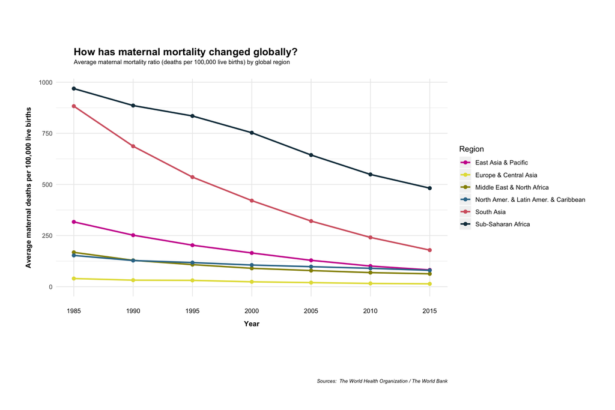

```r
###############
#  LINEGRAPH  #
###############

#### Create new data frame for world regions

copy_merged_WHO_WB_data <- merged_WHO_WB_data
copy_merged_WHO_WB_data$Region[copy_merged_WHO_WB_data$Region %in% c("North America", "Latin America & Caribbean")] <- "North Amer. & Latin Amer. & Caribbean"


# group and summarize merged WHO and WB data into a new table based on world region
region_data <- summarize(group_by(copy_merged_WHO_WB_data, year, Region),
                             avg_mmr=round(mean(value, na.rm=TRUE), digits=0))


#### PLOT

region_data2 <- region_data
show_years <- c(2015, 2010, 2005, 2000, 1995, 1990, 1985)
region_data2 <- subset(region_data2, year %in% show_years)

df <- region_data2
linegraph <- ggplot(data = df,
       aes(x = year, y = avg_mmr, group = Region)) +
  geom_line(aes(color = Region), size = 1) +
  geom_point(aes(color = Region), size = 2) +
  scale_color_manual(values = rev(c("#13394A", "#D4626F", "#357797", "#948E00", "#E3DD44", "#CC149B"))) +
  scale_x_continuous(breaks = seq(1985, 2015, 5)) +
  labs(title = "",
       subtitle = "",
       caption = "Sources:  The World Health Organization / The World Bank") +
  xlab("Year") +
  ylab("Average maternal deaths per 100,000 live births") +
  theme(
    axis.title = element_text(size = 10, face = "bold"),
    axis.title.x = element_text(margin = margin(t=0.3, r=0, b=0, l=0, unit="cm")),
    axis.title.y = element_text(margin = margin(t=0, r=0.3, b=0, l=0, unit="cm")),
    axis.text.x = element_text(size=9,
                               color = "black",
                               margin = margin(t=.5, r=0, b=0, l=0, unit="cm")),
    # axis.text.y = element_blank(),
    axis.ticks = element_blank(),

    legend.position = "right",

    panel.border = element_blank(),
    panel.background = element_blank(),
    panel.grid.major.x = element_line(color = "#EBEBEB"),
    panel.grid.minor.x = element_blank(),
    panel.grid.major.y = element_line(color = "#EBEBEB"),
    panel.grid.minor.y = element_line(color = "#EBEBEB"),

    plot.title = element_text(size = 20, face = "bold"),
    plot.subtitle = element_text(size = 10, margin = margin(t=0,r=0,b=1.5,l=0,unit="cm")),
    plot.caption = element_text(size = 7,
                                margin = margin(t=1,r=0,b=0,l=0,unit="in"),
                                hjust = 1,
                                face = "italic"),
    plot.margin = unit(c(.5,.5,.5,.5),"in")
  ) +
  coord_cartesian(xlim = c(1985,2015), ylim = c(1,max(df$avg_mmr)), clip = "off") +
  annotate("text", x = 1985, y = 1150, label = "How has maternal mortality changed globally?", size = 5, hjust = 0, fontface = "bold") +
  annotate("text", x = 1985, y = 1100, label = "Average maternal mortality ratio (deaths per 100,000 live births) by global region", size = 3, hjust = 0)



ggsave("~/Desktop/Data Visualization/DV Maternal Mortality/hwk submission pdfs/assignment2/linegraph.pdf", plot = last_plot(), width = 10, height = 8, units = "in")

plot(last_plot())
```

Overall, maternal mortality ratios around the world have decreased in the last 30 years. However, maternal mortality remains high among childbearing women in Sub-Saharan African countries (482 maternal deaths per 100,000 live births). South Asian countries had a significant drop in maternal mortality, from 883 deaths to 179 deaths per live births.

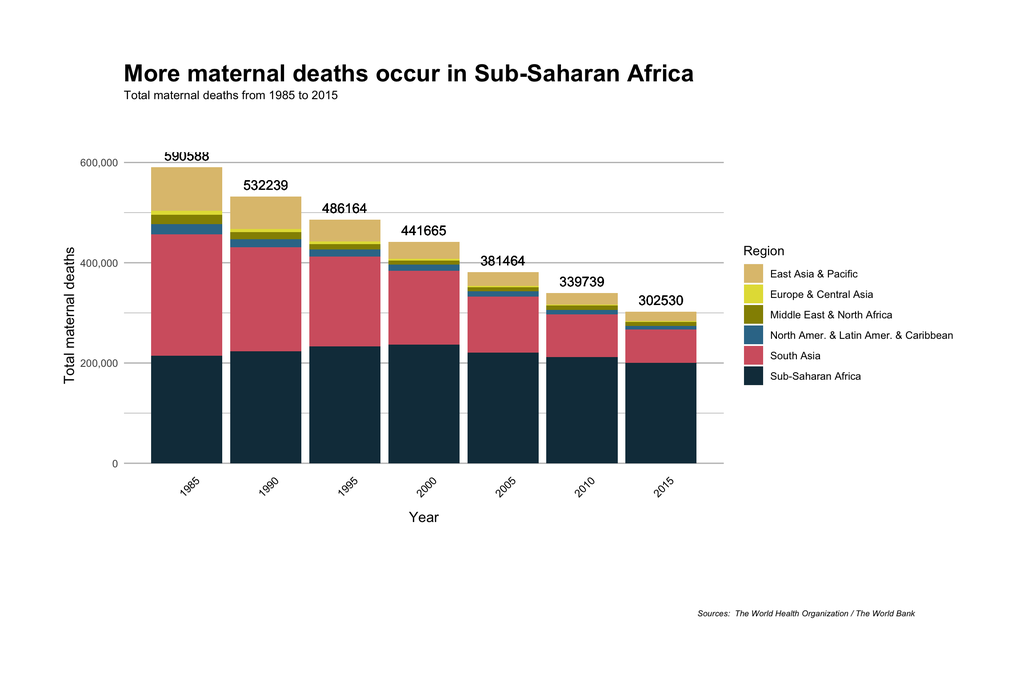

```r
#######################
#  STACKED BAR CHART  #
#######################


#### PREP

# read in World Health Organization data
WHO_data <- read.csv("data/WHO_MMR-data-1990-2015 (1)/countryresults_all.csv")

# read and clean World Bank data
WorldBank_data <- read_excel("data/old data/world bank data.xlsx")
WorldBank_data <- WorldBank_data[-c(1),]
WorldBank_data <- WorldBank_data[,-c(1,2,5)]

# create a new table of maternal mortality ratio point estimates
matdeath_data <- filter(WHO_data,
                   indicator == "matdeaths",
                   estimate == "point estimate",
                   rounded == "TRUE")

# merge WHO and WB data
new_data <- sqldf("SELECT * from matdeath_data
                  LEFT OUTER join WorldBank_data
                  ON matdeath_data.iso = WorldBank_data.Code")

show_years <- c(2015, 2010, 2005, 2000, 1995, 1990, 1985)
new_data <- subset(new_data, year %in% show_years)


rollup_new_data <- new_data
rollup_new_data$Region[rollup_new_data$Region %in% c("North America", "Latin America & Caribbean")] <- "North Amer. & Latin Amer. & Caribbean"


# group and summarize into a new table
sum_region_data <- summarize(group_by(rollup_new_data, year, Region),
                             total_matdeaths_region = round(sum(value, na.rm=TRUE), digits=0))


sum_year_data <- summarize(group_by(sum_region_data, year),
                             total_matdeaths_year = sum(total_matdeaths_region, na.rm=TRUE))

merge_data <- merge(sum_region_data, sum_year_data, by="year")

df <- merge_data

#### PLOT

stackedbar <- ggplot(df, aes(x = year, y = total_matdeaths_region, fill = Region)) +
  geom_bar(stat = "identity") +
  scale_fill_manual(values = rev(c("#13394A", "#D4626F", "#357797",
                                   "#948E00", "#E3DD44", "#DFC27D"))) +
  # coord_flip() +
  # scale_x_reverse(breaks = seq(1985, 2015, 5)) +
  scale_x_continuous(breaks = seq(1985, 2015, 5)) +
  scale_y_continuous(labels = scales::comma) +
  geom_text(aes(y = total_matdeaths_year, label = total_matdeaths_year),
            size = 4, vjust = -.7, colour = "black") +
  labs(title = "More maternal deaths occur in Sub-Saharan Africa",
       subtitle = "Total maternal deaths from 1985 to 2015",
       caption = "Sources:  The World Health Organization / The World Bank") +
  xlab("Year") +
  ylab("Total maternal deaths") +
  theme(
    axis.title = element_text(size = 12),
    axis.text.x = element_text(size=9,
                               color = "black", angle = 45),
    axis.text.y = element_text(),
    axis.ticks = element_blank(),

    legend.background = element_rect(fill = "white"),

    panel.border = element_blank(),
    panel.background = element_blank(),
    panel.grid.major.x = element_blank(),
    panel.grid.minor.x = element_blank(),
    panel.grid.major.y = element_line(colour = "gray"),
    panel.grid.minor.y = element_line(colour = "gray"),
    panel.ontop = FALSE,

    plot.background = element_blank(),
    plot.title = element_text(size = 20, face = "bold"),
    plot.subtitle = element_text(size = 10, margin = margin(t=0,r=0,b=1.5,l=0,unit="cm")),
    plot.caption = element_text(size = 7,
                                margin = margin(t=1,r=0,b=0,l=0,unit="in"),
                                hjust = 1.5,
                                face = "italic"),
    plot.margin = unit(c(.75,.75,.75,.75),"in")
    )

ggsave("~/Desktop/Data Visualization/DV Maternal Mortality/hwk submission pdfs/assignment2/stackedbar.pdf", plot = last_plot(), width = 10, height = 8, units = "in")


plot(stackedbar)
```

Total deaths decrease in all world regions except Sub-Saharan Africa. Sub-Saharan African maternal deaths remain around 200,000. Total maternal deaths in Europe & Central Asia are almost unseen on this graph.

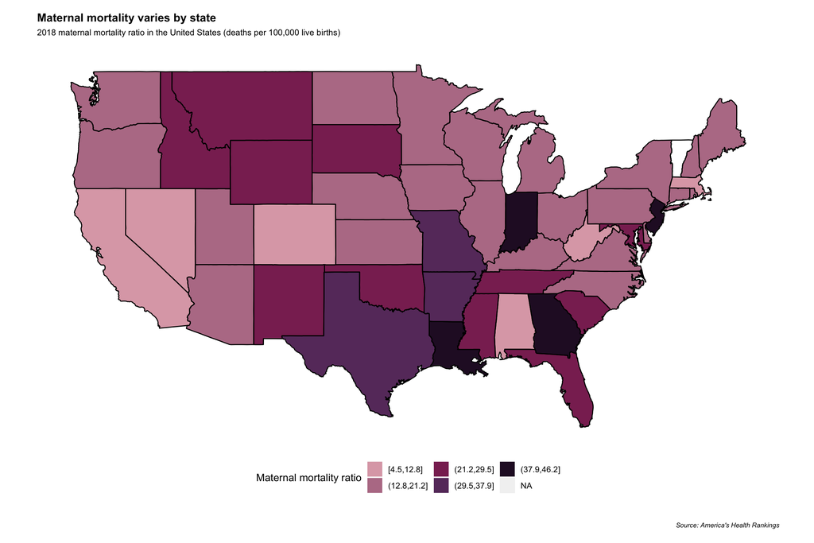

```r
####################
#  CHOROPLETH MAP  #
####################

AHR_data <- read.csv("data/2018-HWC (4).csv")

AHR_data_black_mma <- subset(AHR_data, AHR_data$Measure.Name == "Maternal Mortality - Black")
AHR_data_overall_mma <- subset(AHR_data, AHR_data$Measure.Name == "Maternal Mortality")
AHR_data_AIAN_mma <- subset(AHR_data, AHR_data$Measure.Name == "Maternal Mortality - AIAN")
AHR_data_AsianPacIsl_mma <- subset(AHR_data, AHR_data$Measure.Name == "Maternal Mortality - Asian/Pacific Islander")
AHR_data_Hispanic_mma <- subset(AHR_data, AHR_data$Measure.Name == "Maternal Mortality - Hispanic")
AHR_data_white_mma <- subset(AHR_data, AHR_data$Measure.Name == "Maternal Mortality - White")

states <- map_data("state")


####  PLOT

AHR_data_overall_mma$region <- tolower(AHR_data_overall_mma$State.Name)
AHR_data_overall_mma$bucket <- cut_interval(AHR_data_overall_mma$Value, n = 5)
US_mmr <- merge(states, AHR_data_overall_mma, by="region", all.x=T)
US_mmr <- US_mmr[order(US_mmr$order),]
choropleth_USmmr <- ggplot(US_mmr, aes(x=long,y=lat,group=group))+
  geom_polygon(aes(fill=factor(bucket)))+
  geom_path()+
  # scale fill follow low to high mmr
  # scale_fill_manual("MMR", values = brewer.pal(5, "Greens"), guide = "legend") +
  scale_fill_manual("Maternal mortality ratio", values = c("#DDA8B5", "#B87D95", "#8A2D61", "#68396B", "#29102E"), guide = "legend") +
  # geom_path(color="#FFCDFF") +
  # scale_fill_gradientn(colours=rev(heat.colors(10)),na.value="grey90")+
  coord_map() +
  labs(title = "Maternal mortality varies by state",
       subtitle = "2018 maternal mortality ratio in the United States (deaths per 100,000 live births)",
       caption = "Source: America's Health Rankings") +
  theme(
    axis.title = element_blank(),
    axis.title.x = element_blank(),
    axis.title.y = element_blank(),
    axis.text.x = element_blank(),
    axis.text.y = element_blank(),
    axis.ticks = element_blank(),

    legend.position = "bottom",

    panel.border = element_blank(),
    panel.grid.major.y = element_blank(),
    panel.grid.minor.y = element_blank(),
    panel.grid.major.x = element_blank(),
    panel.grid.minor.x = element_blank(),
    panel.background = element_rect(fill = "white"),

    plot.title = element_text(size = 12, face = "bold"),
    plot.subtitle = element_text(size = 9),
    plot.caption = element_text(size = 7,
                                margin = margin(t=.35,r=0,b=0,l=0,unit="in"),
                                hjust = 1,
                                face = "italic"),
    plot.margin = unit(c(.5,.5,.5,.5),"cm"),
    plot.background = element_rect(fill = "white")
  )


ggsave("~/Desktop/Data Visualization/DV Maternal Mortality/hwk submission pdfs/assignment2/choropleth_USmmr.pdf", plot = last_plot(), width = 10, height = 8, units = "in")


plot(choropleth_USmmr)
```

```r
#code for heatmap of US from https://stackoverflow.com/questions/24441775/how-do-you-create-a-us-states-heatmap-based-on-some-values
```

Above visualizes maternal mortality per 100,000 live births, where measurement of maternal mortality extends from deaths occurred during gestation up to the first 42 days after termination of pregnancy. Southern/south western states show higher prevalence of maternal deaths. Only a few states (California, Nevada, Colorado, Alabama, West Virginia, and Massachusetts) have low mortality ratios.

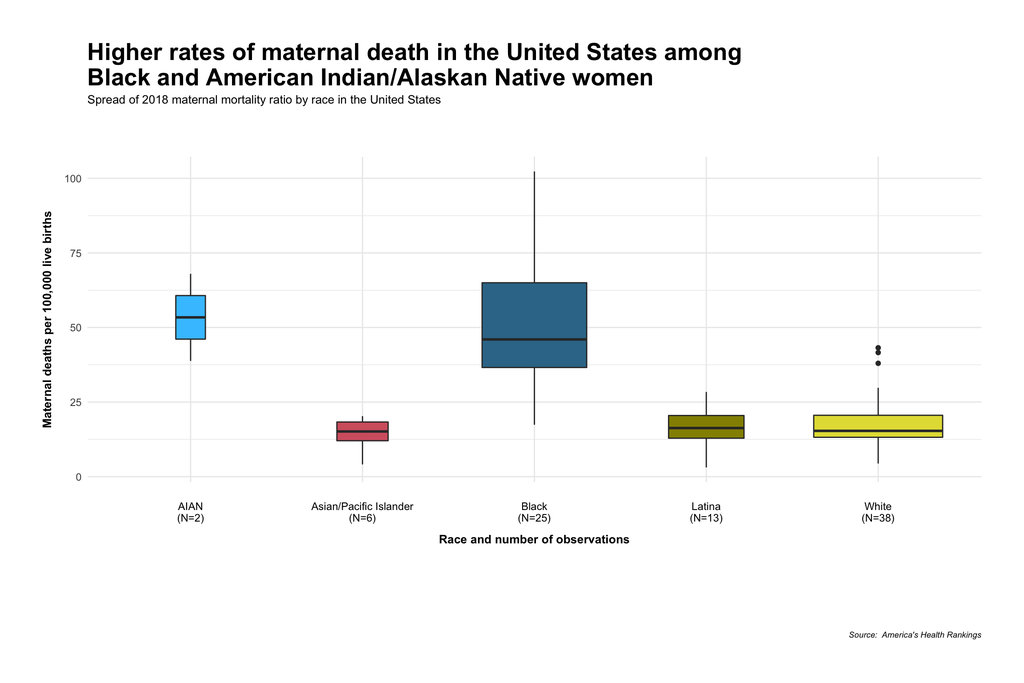

```r
##############
#  BOX PLOT  #
##############
keep <- c("Maternal Mortality - AIAN","Maternal Mortality - Asian/Pacific Islander","Maternal Mortality - Black","Maternal Mortality - Hispanic","Maternal Mortality - White")
AHR_mmr_by_race <- filter(AHR_data, AHR_data$Measure.Name %in% keep)

AHR_mmr_by_race <- drop_na(AHR_mmr_by_race, c("Value"))

AHR_mmr_by_race <- mutate(AHR_mmr_by_race, Race = case_when(Measure.Name == "Maternal Mortality - AIAN" ~ "AIAN",
                                                            Measure.Name == "Maternal Mortality - Asian/Pacific Islander" ~ "Asian/Pacific Islander",
                                                            Measure.Name == "Maternal Mortality - Black" ~ "Black",
                                                            Measure.Name == "Maternal Mortality - Hispanic" ~ "Latina",
                                                            Measure.Name == "Maternal Mortality - White" ~ "White"))

my_xlab <- paste(unique(AHR_mmr_by_race$Race),"\n(N=",table(AHR_mmr_by_race$Race),")",sep="")

boxplot_mmr_by_race <- ggplot(AHR_mmr_by_race) +
  geom_boxplot(aes(x=Measure.Name, y=Value, fill=Measure.Name), varwidth = TRUE, alpha = 1) +
  scale_fill_manual(values = c("#41C4FF", "#D4626F", "#357797", "#948E00", "#E3DD44")) +
  # scale_fill_manual(values = c("#FF5E35", "#5E1742", "#C9463D", "#76027D", "#962E40")) +
  scale_x_discrete(labels=my_xlab) +
  labs(title = "Higher rates of maternal death in the United States among \nBlack and American Indian/Alaskan Native women",
       subtitle = "Spread of 2018 maternal mortality ratio by race in the United States",
       caption = "Source:  America's Health Rankings") +
  xlab("Race and number of observations") +
  ylab("Maternal deaths per 100,000 live births") +
  theme(
    axis.title = element_text(size = 10, face = "bold"),
    axis.title.x = element_text(margin = margin(t=0.3, r=0, b=0, l=0, unit="cm")),
    axis.title.y = element_text(margin = margin(t=0, r=0.3, b=0, l=0, unit="cm")),
    axis.text.x = element_text(size=9,
                               color = "black",
                               margin = margin(t=.5, r=0, b=0, l=0, unit="cm")),
    axis.text.y = element_text(),
    axis.ticks = element_blank(),

    legend.position = "none",

    panel.border = element_blank(),
    panel.background = element_blank(),
    panel.grid.major.x = element_line(color = "#EBEBEB"),
    panel.grid.minor.x = element_blank(),
    panel.grid.major.y = element_line(color = "#EBEBEB"),
    panel.grid.minor.y = element_line(color = "#EBEBEB"),

    plot.title = element_text(size = 20, face = "bold"),
    plot.subtitle = element_text(size = 10, margin = margin(t=0,r=0,b=1.5,l=0,unit="cm")),
    plot.caption = element_text(size = 7,
                                margin = margin(t=1,r=0,b=0,l=0,unit="in"),
                                hjust = 1,
                                face = "italic"),
    plot.margin = unit(c(.5,.5,.5,.5),"in")
  )


ggsave("~/Desktop/Data Visualization/DV Maternal Mortality/hwk submission pdfs/assignment2/boxplot_mmr_by_race.pdf", plot = last_plot(), width = 10, height = 8, units = "in")

plot(boxplot_mmr_by_race)
```

```r
# code from: https://www.r-graph-gallery.com/266-ggplot2-boxplot-with-variable-width/
```

The width of the box plot helps to understand how much data collection regarding maternal deaths and racial breakouts has occurred. The maximum number of observations which could have occurred per race is 51, for all states and the District of Columbia. Black American women die at higher ratios, 102 deaths being the highest recorded number of deaths per 100,000 live births. American Indian/Alaskan Native women have the highest median maternal death ratio, hovering just above 50.

DATA SOURCES:

- The World Bank: https://datahelpdesk.worldbank.org/knowledgebase/articles/906519-world-bank-country-and-lending-groups
- The World Health Organization: https://www.who.int/reproductivehealth/publications/monitoring/maternal-mortality-2015/en/
- America’s Health Rankings: https://www.americashealthrankings.org/explore/health-of-women-and-children/measure/maternal_mortality/state/ALL